| title: “Brownlows Bets” |
| --- |
| author: “Calista Densing” |
| date: “October 16, 2019” |
| output: html_document: default |

# Introduction

At the first day of class there are 35 students in Math Statistics class and professor Brownlow always proposes this bet to his students “I will wager $2 to your bet of $1 that at least two people in today’s class have the same birthday. He tells me he has made that bet 1137 times so far. Where do you think his profits are? Discuss this in a markdown document

# Methods

We will create a dataset containing all of the days of the year. Then we will run the sample with replacements 1,137 times. We take a sample of 35, if two come out the same, Brownlow gets one dollar, if they don’t come out the same, he will lose two. This will be repeated 1,137 times.We will then set up a histogram containing our output. swe will create barriers, with 2.5% of the winnings on either side, therefore the middle displays 95% confidence.

# Profit Estimate

Firstly we create the year data and a vector to contain samples.

```r
Bdays = 1:365
Bsamples = vector('numeric')
TotalDollars = 0
saveDollars=vector('numeric')
```

Now we will run the simulation 1,137 times.

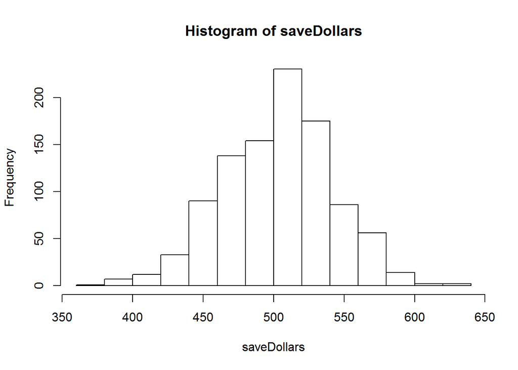

```r
for(loop in 1:1000){
TotalDollars=0
for(i in 1:1137) {
Bsamples = sample(Bdays,35, replace=TRUE)
if (length(unique(Bsamples)) == 35) {
TotalDollars = TotalDollars -2
} else{
TotalDollars = TotalDollars +1
}
}
saveDollars[loop] = TotalDollars
}
hist(saveDollars)
```

```r
print(mean(saveDollars))
```

```
## [1] 503.796
```

# Confidence interval of Brownlows earning

```r
stdevDollars = sd(saveDollars)
meanDollars=mean(saveDollars)
CI = c(meanDollars-2*stdevDollars, meanDollars+2*stdevDollars)
print(CI)
```

```
## [1] 424.6521 582.9399
```

# Discussion and Conclusion

To adjust the payout, he could change his win to +1 and his losses to -4.50 which would center it at about zero. To adjust the class size, it would have to be about 28 or 29, then his payout woud be centered around zero.